# Project 2: Data Mining, Classification, Prediction

SDS322E

# Mining, Classification, Prediction

## Jack Rickman jhr2368

### Introduction

#### 1. num: garageSpaces; Number of garage spaces. This is a subset of the ParkingSpaces feature.

#### 2. bool: hasAssociation; Indicates if there is a Homeowners Association associated with the listing. (T/F:8007:7164)

#### 3. bool: hasSpa; Boolean indicating if the home has a Spa (T/F: 1199:14k)

#### 4. num: parkingSpaces; The number of parking spots that come with a home.

#### 5. date: yearBuilt; The year the property was built.

#### 6. num; latestPrice; The most recent available price at time of data acquisition.

#### 7. num; numOfBedrooms; The number of bedrooms in a property.

#### 8. num; numOfStories; The number of stories a property has.

#### 9. num; numOfBathrooms; The number of bathrooms in a property.

#### 10. num; livingAreaSqFt; The living area of the property reported in Square Feet.

#### 11. num; lotSizeSqFt; The lot size of the property reported in Square Feet.

#### 12. num; numOfSecurityFeatures; The number of unique security features in the Zillow listing.

#### 13. num; numOfAppliances; The number of unique appliances in the Zillow listing.

```r
library(tidyverse)
# read your datasets in here, e.g., with read_csv()
austinHousingData <- read.csv("~/Downloads/austinHousingData.csv", comment.char="#")
# dim(austinHousingData)
attach(austinHousingData)
str(austinHousingData)
```

```
## 'data.frame':    13105 obs. of  47 variables:
##  $ zpid                      : chr  "111373431" "120900430" "2084491383" "120901374" ...
##  $ city                      : chr  "pflugerville" "pflugerville" "pflugerville" "pflugerville" ...
##  $ streetAddress             : chr  "14424 Lake Victor Dr" "1104 Strickling Dr" "1408 Fort Dessau Rd" "1025 Strickling Dr" ...
##  $ zipcode                   : chr  "78660" "78660" "78660" "78660" ...
##  $ description               : chr  "14424 Lake Victor Dr, Pflugerville, TX 78660 is a single family home that contains 2,601 sq ft and was built in"| __truncated__ "Absolutely GORGEOUS 4 Bedroom home with 2 full baths located in the tucked away Pflugerville community The Lake"| __truncated__ "Un…
##  $ latitude                  : chr  "30.43063163757324" "30.43267250061035" "30.409748077392567" "30.432111740112305" ...
##  $ longitude                 : chr  "-97.66307830810548" "-97.66169738769531" "-97.6397705078125" "-97.66165924072266" ...
##  $ propertyTaxRate           : chr  "1.98" "1.98" "1.98" "1.98" ...
##  $ garageSpaces              : chr  "2" "2" "0" "2" ...
##  $ hasAssociation            : chr  "True" "True" "True" "True" ...
##  $ hasCooling                : chr  "True" "True" "True" "True" ...
##  $ hasGarage                 : chr  "True" "True" "False" "True" ...
##  $ hasHeating                : chr  "True" "True" "True" "True" ...
##  $ hasSpa                    : chr  "False" "False" "False" "False" ...
```

[output cut: 33 more lines]

```r
df_num <- austinHousingData %>% select(latestPrice,numOfBedrooms, numOfStories, numOfBathrooms, garageSpaces, parkingSpaces,livingAreaSqFt, lotSizeSqFt, numOfSecurityFeatures, numOfAppliances, yearBuilt ) %>% as.data.frame() %>% mutate_if(is.character,as.numeric)
df_bool <- austinHousingData %>% select(hasAssociation, hasSpa)  %>% as.data.frame() %>% mutate_if(is.character,as.logical)

df <- bind_cols(df_num, df_bool)
dim(df)
```

```
## [1] 13105    13
```

```r
# See how many NA's per variable
df %>%select(everything()) %>% summarise_all(funs(sum(is.na(.))))
```

```
##   latestPrice numOfBedrooms numOfStories numOfBathrooms garageSpaces
## 1        5313          5313         5312           5313         5308
##   parkingSpaces livingAreaSqFt lotSizeSqFt numOfSecurityFeatures
## 1          5312           5310        5312                  5312
##   numOfAppliances yearBuilt hasAssociation hasSpa
## 1            5309      5311           5313   5313
```

```r
# Remove NA's
df <- df %>% na.omit()
# Check to see no more NA's
map(df, ~sum(is.na(.)))
```

```
## $latestPrice
## [1] 0
##
## $numOfBedrooms
## [1] 0
##
## $numOfStories
## [1] 0
##
## $numOfBathrooms
## [1] 0
##
## $garageSpaces
## [1] 0
##
## $parkingSpaces
## [1] 0
##
## $livingAreaSqFt
## [1] 0
##
## $lotSizeSqFt
## [1] 0
##
## $numOfSecurityFeatures
## [1] 0
##
## $numOfAppliances
## [1] 0
##
## $yearBuilt
## [1] 0
##
## $hasAssociation
## [1] 0
##
## $hasSpa
## [1] 0
```

### Cluster Analysis

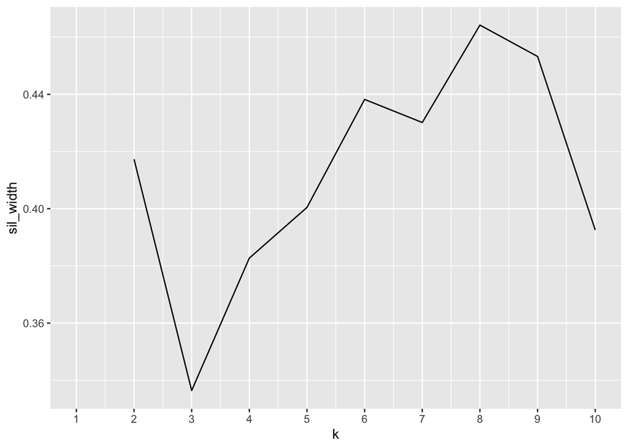

```r
library(cluster) #load the cluster package
library(ggplot2)
library(GGally)
set.seed(322) #just makes our output match

df_scale1 <- df %>% select(livingAreaSqFt, lotSizeSqFt, numOfBedrooms, latestPrice) %>% scale %>% as.data.frame()
df_scale1  <-  cbind(df_scale1, hasAssociation = df$hasAssociation)

# Goodness-of-Fit and Number of Clusters in PAM
sil_width<-vector()
for(i in 2:10){
  pam_fit <- pam(df_scale1, k = i)
  sil_width[i] <- pam_fit$silinfo$avg.width
}
ggplot()+geom_line(aes(x=1:10,y=sil_width))+scale_x_continuous(name="k",breaks=1:10)
```

[figure not shown]

```r
# From the plot, the suggested number of clusters is 8. Next we’ll classify the
# observations into 8 clusters. The average silhouette width shows there is a
# weak structure, ~0.46.
pam8 <- pam(df_scale1, k = 8)
plot(pam8,which=2)
```

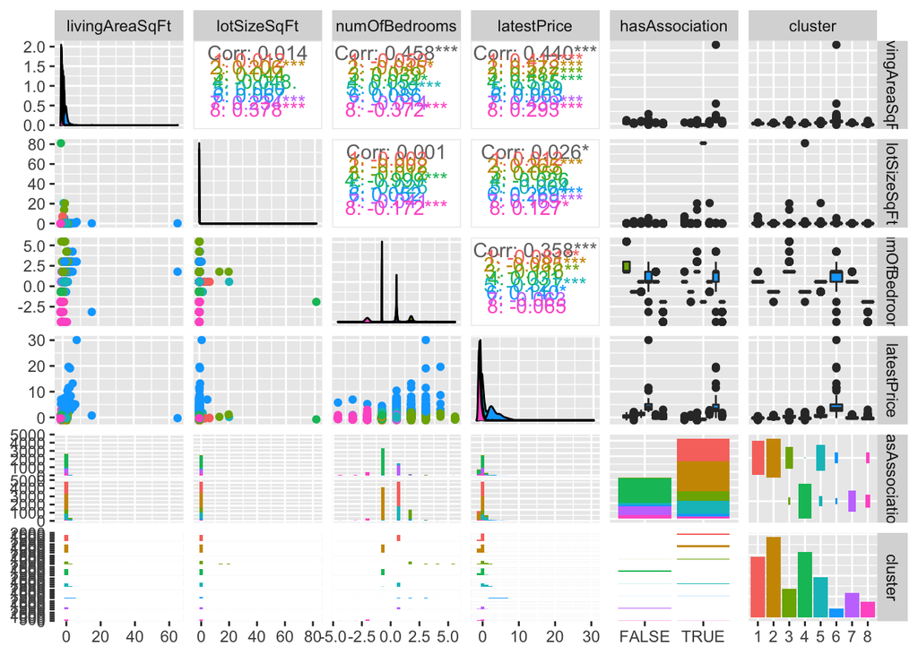

```r
# graph clusters of each pair of variables
pamclust<-df_scale1 %>% mutate(cluster=as.factor(pam8$clustering))

ggpairs(pamclust, ggplot2::aes(color=cluster))
```

```r
# Summarize clusters & interpret
pamclust %>% group_by(cluster) %>% summarize_if(is.numeric,mean,na.rm=T)
```

```
## # A tibble: 8 × 5
##   cluster livingAreaSqFt lotSizeSqFt numOfBedrooms latestPrice
##   <fct>            <dbl>       <dbl>         <dbl>       <dbl>
## 1 1               0.0688     -0.0168         0.548      -0.251
## 2 2              -0.297      -0.0331        -0.685      -0.366
## 3 3               0.785       0.0395         1.91        0.318
## 4 4              -0.498       0.0253        -0.684      -0.294
## 5 5               0.653       0.0256         0.472       0.675
## 6 6               2.26        0.106          1.41        4.18
## 7 7              -0.186      -0.0224         0.575      -0.136
## 8 8              -0.724      -0.0319        -2.14       -0.329
```

*We see that the PAM clustering did not seperate the groups very clearly. The cluster that is most interesting is the 6th cluster. It shows that the living area square feet for cluster 6 has values 2.26 deviations above the overall average. Also the latest price for cluster 6 has values 4.18 deviations above the overall average. Not really any of the other clusters are very interesting. The overall goodness of fit is not good from the weak average silhouette width of 0.46.*

### Dimensionality Reduction with PCA

```r
library(factoextra)
pca<- df %>% select_if(is.numeric) %>% prcomp(scale = TRUE)
summary(pca, loadings=T)
```

```
## Importance of components:
##                           PC1    PC2    PC3     PC4     PC5    PC6     PC7
## Standard deviation     1.7937 1.3597 1.0672 1.00095 0.95254 0.9292 0.81930
## Proportion of Variance 0.2925 0.1681 0.1035 0.09108 0.08248 0.0785 0.06102
## Cumulative Proportion  0.2925 0.4606 0.5641 0.65519 0.73767 0.8162 0.87719
##                            PC8     PC9    PC10    PC11
## Standard deviation     0.74716 0.73636 0.49789 0.05020
## Proportion of Variance 0.05075 0.04929 0.02254 0.00023
## Cumulative Proportion  0.92794 0.97724 0.99977 1.00000
```

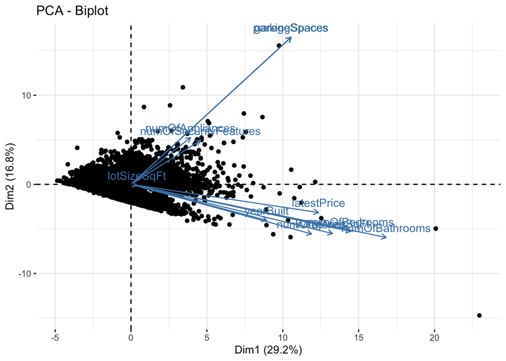

```r
fviz_pca_biplot(pca, geom = c("point"))
```

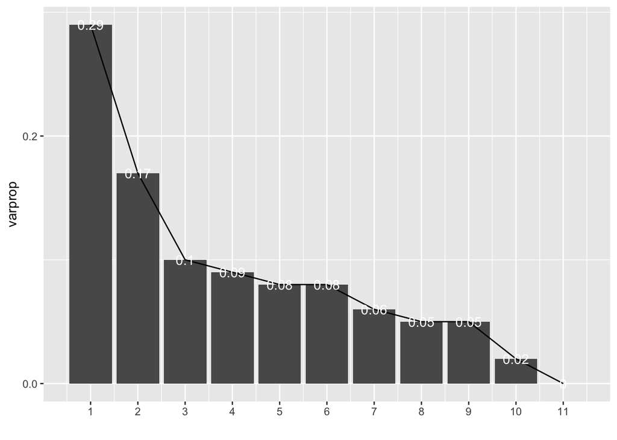

```r
eigval<-pca$sdev^2 #square to convert SDs to eigenvalues
varprop=round(eigval/sum(eigval), 2) #proportion of var explained by each PC
ggplot() + geom_bar(aes(y=varprop, x=1:11), stat="identity") + xlab("") + geom_path(aes(y=varprop, x=1:11)) + geom_text(aes(x=1:11, y=varprop, label=round(varprop, 2)), col="white") + scale_y_continuous(breaks=seq(0, .6, .2)) + scale_x_continuous(breaks=1:11)
```

```r
# We will keep 6 principle components for it gives us a cumulative proportion of
# variance above 80%.

# highest PC1
pca$x[,1:6] %>% as.data.frame %>% arrange(desc(PC1)) %>% head(3)
```

```
##           PC1        PC2        PC3        PC4       PC5      PC6
## 705  22.95608 -14.718380 -11.050855 -0.3494125  6.898128 8.119436
## 2224 20.07886  -4.965796 -14.388660 -2.6875520 12.209706 5.905356
## 279  12.54101  -3.795603  -9.453106 -0.7381746  8.128641 3.061189
```

```r
# lowest PC1
pca$x[,1:6] %>% as.data.frame %>% arrange(PC1) %>% head(3)
```

```
##             PC1       PC2        PC3         PC4        PC5       PC6
## 1034  -4.857627 0.4134843 -0.9569537  0.05345370 -0.6028586 0.8781642
## 12945 -4.707233 0.4094218 -1.9258525  0.04631675  0.4225310 0.7699811
## 335   -4.636576 0.3742661 -1.9486260 -0.02861059  0.4813851 0.9857806
```

```r
# highest on PC2
pca$x[,1:6] %>% as.data.frame %>% arrange(desc(PC2)) %>% head(3)
```

```
##           PC1       PC2        PC3          PC4        PC5        PC6
## 4126 9.750992 15.565030 -3.2540234 -0.066898039 -3.6456441 -1.6993359
## 6222 3.416187 10.889341 -1.0584804  0.009027383  0.5146861 -0.4887848
## 8316 2.572298  8.859443 -0.3402438  0.195302183 -0.6811204  1.7352857
```

```r
# lowest on PC2
pca$x[,1:6] %>% as.data.frame %>% arrange(PC2) %>% head(3)
```

```
##            PC1        PC2        PC3        PC4      PC5      PC6
## 705  22.956081 -14.718380 -11.050855 -0.3494125 6.898128 8.119436
## 1210 10.511280  -5.924451  -8.547466 -1.2533482 9.057017 2.871080
## 1272  9.370199  -5.600867  -5.685157 -1.1553774 6.172114 1.910610
```

```r
# highest on PC3
pca$x[,1:6] %>% as.data.frame %>% arrange(desc(PC3)) %>% head(3)
```

```
##            PC1        PC2      PC3        PC4       PC5       PC6
## 8296 0.9578253  0.5384941 4.644329 -0.3575836 0.7783766 0.7962831
## 4271 2.0734697 -0.5342878 4.553102 -0.5749260 2.7987330 2.1988369
## 3561 0.3322496 -0.1371839 4.348522 -0.4467956 1.5585071 1.4554023
```

```r
# lowest on PC3
pca$x[,1:6] %>% as.data.frame %>% arrange(PC3) %>% head(3)
```

```
##           PC1        PC2        PC3        PC4       PC5      PC6
## 2224 20.07886  -4.965796 -14.388660 -2.6875520 12.209706 5.905356
## 705  22.95608 -14.718380 -11.050855 -0.3494125  6.898128 8.119436
## 279  12.54101  -3.795603  -9.453106 -0.7381746  8.128641 3.061189
```

```r
# highest on PC4
pca$x[,1:6] %>% as.data.frame %>% arrange(desc(PC4)) %>% head(3)
```

```
##            PC1      PC2       PC3       PC4       PC5         PC6
## 11522 5.297981 4.073930 -2.897327 0.8071321 -2.383288 -0.20916352
## 5975  4.189339 4.515154 -3.169075 0.7406106 -2.422941  0.03363889
## 13099 7.366068 5.265370 -3.010759 0.6777376 -2.833817  0.28592563
```

```r
# lowest on PC4
pca$x[,1:6] %>% as.data.frame %>% arrange(PC4) %>% head(3)
```

```
##            PC1        PC2       PC3       PC4        PC5        PC6
## 8359 -2.395517 -0.1050553 -5.587142 -79.98501 -11.176379  0.7835246
## 2248  1.595573 -0.1219028 -1.210176 -20.23290  -3.826120 -0.4367152
## 4228  4.439844 -0.3827036 -1.982562 -19.87910  -3.467842 -0.3344830
```

```r
# highest on PC5
pca$x[,1:6] %>% as.data.frame %>% arrange(desc(PC5)) %>% head(3)
```

```
##           PC1       PC2        PC3        PC4       PC5      PC6
## 2224 20.07886 -4.965796 -14.388660 -2.6875520 12.209706 5.905356
## 1210 10.51128 -5.924451  -8.547466 -1.2533482  9.057017 2.871080
## 279  12.54101 -3.795603  -9.453106 -0.7381746  8.128641 3.061189
```

```r
# lowest on PC5
pca$x[,1:6] %>% as.data.frame %>% arrange(PC5) %>% head(3)
```

```
##            PC1        PC2       PC3          PC4        PC5        PC6
## 8359 -2.395517 -0.1050553 -5.587142 -79.98500604 -11.176379  0.7835246
## 2248  1.595573 -0.1219028 -1.210176 -20.23290375  -3.826120 -0.4367152
## 4126  9.750992 15.5650302 -3.254023  -0.06689804  -3.645644 -1.6993359
```

```r
# highest on PC6
pca$x[,1:6] %>% as.data.frame %>% arrange(desc(PC6)) %>% head(3)
```

```
##            PC1        PC2        PC3        PC4       PC5      PC6
## 705  22.956081 -14.718380 -11.050855 -0.3494125  6.898128 8.119436
## 2224 20.078856  -4.965796 -14.388660 -2.6875520 12.209706 5.905356
## 7504  2.492364   1.129260   4.179849 -0.2428257  1.035057 4.112971
```

```r
# lowest on PC6
pca$x[,1:6] %>% as.data.frame %>% arrange(PC6) %>% head(3)
```

```
##             PC1        PC2       PC3         PC4       PC5       PC6
## 1422  2.9120340 -0.2743484 0.5626034 -0.17388124 0.9113256 -2.774953
## 11218 0.5990265 -0.2515479 1.7929323 -0.19928020 0.3621503 -2.769387
## 11213 0.3378451  0.8422994 0.6677536 -0.07940264 0.4944489 -2.675699
```

*These are the highest and lowest scores of each of the principle components that we keep. When we keep the first 6 components, this explains 81% of the variance of the total data set. When we look at some of the scores of our observations, we find that observation 705 scores the highest on the 1st PC and the lowest on the 2nd PC. Also this observation scored the 2nd lowest on the 3rd PC!*

### Linear Classifier

```r
library(caret)
# We will be using logistic regression for our linear classifier.
df1 <- df %>% select(hasAssociation, latestPrice,numOfBedrooms, numOfStories, numOfBathrooms, garageSpaces, parkingSpaces,livingAreaSqFt, lotSizeSqFt, numOfSecurityFeatures, numOfAppliances, yearBuilt )
df1$hasAssociation <- as.factor(1*df1$hasAssociation)
fit <- glm(hasAssociation~., data = df1, family = "binomial")
score <- predict(fit, type="response")
class_diag(score,truth=df1$hasAssociation, positive=1)
```

```
##            acc   sens   spec    ppv     f1     ba    auc
## Metrics 0.8574 0.9059 0.7632 0.8814 0.8935 0.8346 0.9087
```

```r
# Pretty good AUC at about 91% !
df1$pred_glm <- ifelse(score > 0.5, 1, 0)
confusionMatrix(as.factor(df1$hasAssociation), as.factor(df1$pred_glm))
```

```
## Confusion Matrix and Statistics
##
##           Reference
## Prediction    0    1
##          0 2021  627
##          1  484 4660
##
##                Accuracy : 0.8574
##                  95% CI : (0.8495, 0.8651)
##     No Information Rate : 0.6785
##     P-Value [Acc > NIR] : < 2.2e-16
##
##                   Kappa : 0.678
##
##  Mcnemar's Test P-Value : 2.042e-05
##
##             Sensitivity : 0.8068
##             Specificity : 0.8814
##          Pos Pred Value : 0.7632
##          Neg Pred Value : 0.9059
##              Prevalence : 0.3215
##          Detection Rate : 0.2594
##    Detection Prevalence : 0.3398
##       Balanced Accuracy : 0.8441
##
##        'Positive' Class : 0
##
```

```r
# Our confusion matrix has the model at about 86% accuracy!
```

```r
# k-fold CV
set.seed(1234)
k=10 #let's use k=5, since our dataset is medium size
folds<-cut(seq(1:nrow(df1)),breaks=k,labels=F) #create folds
diags<-NULL
for(i in 1:k){
  ## Create training and test sets
  train<-df1[folds!=i,]
  test<-df1[folds==i,]
  truth<-test$hasAssociation
  ## Train model on training set
  fit<-glm(hasAssociation~.,data=train,family="binomial")
  probs<-predict(fit,newdata = test,type="response")
  ## Test model on test set (save all k results)
  diags<-rbind(diags,class_diag(probs,truth, positive=1))
}
summarize_all(diags,mean)
```

```
##       acc    sens   spec    ppv      f1      ba     auc
## 1 0.85717 0.89334 0.7308 0.8635 0.87713 0.81206 0.87868
```

*WE see that the cross validation logistic regression model does slighlty worse compared to the model training on all the observations. We expect this because we were probably overfitting the model. The 87% AUC will probably be much more of an accurate representation of the logistic model!*

### Non-Parametric Classifier

```r
fit<-knn3(hasAssociation~.,data=df1)
score <- predict(fit, newdata = df1)[,2]
class_diag(score,truth=df1$hasAssociation, positive=1)
```

```
##            acc   sens   spec    ppv     f1    ba    auc
## Metrics 0.8228 0.9156 0.6424 0.8326 0.8721 0.779 0.8879
```

```r
df1$pred_knn <- ifelse(score > 0.5, 1, 0)
confusionMatrix(as.factor(df1$hasAssociation), as.factor(df1$pred_knn))
```

```
## Confusion Matrix and Statistics
##
##           Reference
## Prediction    0    1
##          0 1701  947
##          1  434 4710
##
##                Accuracy : 0.8228
##                  95% CI : (0.8141, 0.8312)
##     No Information Rate : 0.726
##     P-Value [Acc > NIR] : < 2.2e-16
##
##                   Kappa : 0.5855
##
##  Mcnemar's Test P-Value : < 2.2e-16
##
##             Sensitivity : 0.7967
##             Specificity : 0.8326
##          Pos Pred Value : 0.6424
##          Neg Pred Value : 0.9156
##              Prevalence : 0.2740
##          Detection Rate : 0.2183
##    Detection Prevalence : 0.3398
##       Balanced Accuracy : 0.8147
##
##        'Positive' Class : 0
##
```

```r
# k-fold CV
set.seed(1234)
k=10 #let's use k=5, since our dataset is medium size
folds<-cut(seq(1:nrow(df1)),breaks=k,labels=F) #create folds
diags<-NULL
for(i in 1:k){
  ## Create training and test sets
  train<-df1[folds!=i,]
  test<-df1[folds==i,]
  truth<-test$hasAssociation
  ## Train model on training set
  fit<-knn3(hasAssociation~.,data=train)
  probs<-predict(fit,newdata = test)[,2]
  ## Test model on test set (save all k results)
  diags<-rbind(diags,class_diag(probs,truth, positive=1))
}
summarize_all(diags,mean)
```

```
##       acc    sens    spec     ppv      f1      ba     auc
## 1 0.70546 0.83056 0.44376 0.73469 0.77231 0.63716 0.70298
```

*Now for k-near-neighbors model when training on all the observations, gives us an AUC of about 89%. This is very accurate, but knn uses the observations closest to it to make predictions so that model most likely suffers from overfitting. Thus we see in the cross-validation model for knn that the AUC drops to about 70%. This model doesn’t lack from overfitting and makes much more clear the value this knn model brings to this prediction.*

### Regression/Numeric Prediction

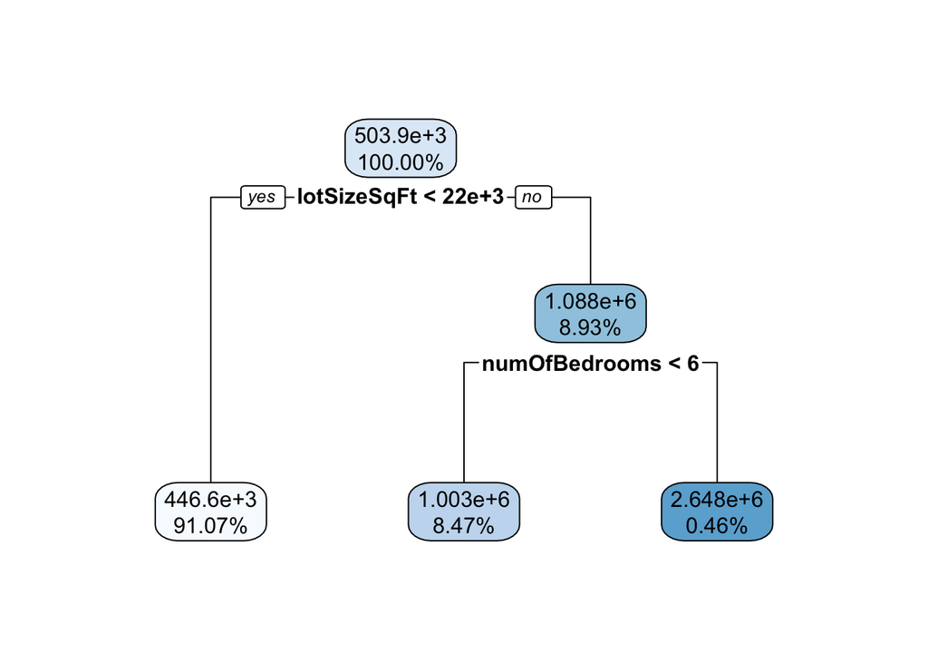

```r
library(rpart)
library(rpart.plot)
fit<-train(latestPrice~lotSizeSqFt+numOfBedrooms+hasAssociation+hasSpa+yearBuilt,data=df, method="rpart")
rpart.plot(fit$finalModel,digits=4)
```

```r
mean(fit$results$RMSE^2) # Average MSE
```

```
## [1] 156590060302
```

```r
# cross-validation of regression tree
set.seed(1234)
cv <- trainControl(method="cv", number = 10, classProbs = T, savePredictions = T)
fit<-train(latestPrice~lotSizeSqFt+numOfBedrooms+as.factor(hasAssociation)+as.factor(hasSpa)+yearBuilt,data=df, trControl=cv, method="rpart")
mean(fit$results$RMSE^2) # average MSE
```

```
## [1] 1.56027e+11
```

*For the regression tree method the model did very poorly. It did not have much accuracy. We have 1xe11 mean square average error term! Practically we would stay away from this model or add different variables that has better predicting power than the current variables.*

### Python

```r
library(reticulate)
use_python("/usr/bin/python3", required = F)
```

```python
from statistics import mean
from statistics import median
from statistics import mode

x = r.df["latestPrice"]
x_mean = mean(x)
x_median = median(x)
x_mode = mode(x)
```

```r
py$x_mean
```

```
## [1] 503897
```

```r
py$x_median
```

```
## [1] 4e+05
```

```r
py$x_mode
```

```
## [1] 325000
```

*From the python code chuck, I got the mean, median, and mode of the latestPrice variable from R. I imported mean, median and mode from the statistics library in python. Then outputed the results back in a R chuck.*